# Inverse Distribution Function

Seoncheol Park

2/14/2020

## $(\Omega, \mathcal{F}, P)= ((0,1), \mathcal{B}_{(0,1)}, \mu_{L})$을 씁시다!

기초확률론에서 우리는 보통 확률변수 $X$의 도메인에 관해 깊게 생각하지 않는다. 그러나 $\Omega=(0,1)$, $\mathcal{F}=\text{the Borel subsets of }(0,1)$, $P$fmf 르베그 측도 $\mu_{L}$로 사용한다면, 임의의 분포함수 $F$를 갖는 확률분포를 항상 만들어 낼 수 있다.

$F(x)$가 연속이고 strictly increasing일 때 한 번 살펴보자. 만약 $U$가 $(0,1)$에서 uniformly distributed되어있다면 (즉 $P(U\leq u)=u$ for $0 < u <1$), $F^{-1}(U)$는 분포함수 $F$를 갖는다. 왜냐하면

$$\begin{align}
P(F^{-1}(U)\leq x) &= P[F\{F^{-1}(U) \}\leq F(x)]\\
&= P(U\leq F(x)) = F(x)
\end{align}$$

이기 때문이다. 그러나 이러한 논리는 $F$가 (1) 연속이 아니거나 (2) strictly increasing이 아닐 경우 성립하지 않는다. 예를 들면

$$F(x)=
\begin{cases}
0 & x<\frac{1}{2}\\
1 & x\geq \frac{1}{2}
\end{cases}$$

인 경우 $F^{-1}(u)$는 $0<u<1$에서 잘 정의되지 않는다.

그렇지만 이런 경우에도 $F^{-1}(u)$를 살짝 다르게 바꾸어 정의할 수 있다. 우리는 이것을 **inverse probability distribution**이라고 부른다.

**Definition 1 (Inverse probability transformation)** Let $F(x)$ be any distribution function and $0< u <1$. Then the inverse probability transformation $F^{-1}(u)$ is defined to be $\inf \{x: F(x)\geq u \}$.

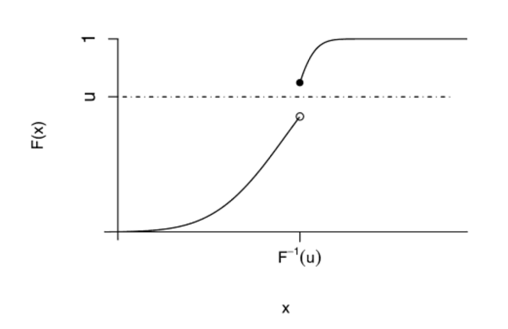

Figure 1: Inverse distribution function.

그림은 $F^{-1}(u)=\inf \{x: F(x)\geq u \}$를 출력하고 있는데 $t<F^{-1}(u)$일 때에는 $F(t)<u$이고 $t\geq F^{-1}(u)$일 때에는 $F(t)\geq u$이다. 따라서 $t\geq F^{-1}(u)$는 $F(t)\geq u$와 같은 개념이 된다.

**Proposition 1** $F(t)\geq u \Leftrightarrow t \geq F^{-1}(u)$.

*Proof.* 두 가지 단계로 증명한다.